# Simple Linear Regression

```r
# Load your libraries
library(pander)
library(car)
library(DT)
library(mosaic)
library(tidyverse)
library(readr)
```

## Background

FromSoftware, the Japanese development studio, is famous for creating the “Souls-like” genre, known for its high difficulty and intricate world-building. Games like *Dark Souls*, *Bloodborne*, and *Elden Ring* have achieved both critical and commercial success.

This analysis seeks to answer the following question: **Is there a linear relationship between the length of a FromSoftware game and its critical reception?**

One might hypothesize that longer games (like *Elden Ring*) are seen as more “epic” and thus receive higher scores. Conversely, one could also argue that shorter, more focused games (like *Sekiro*) are more polished and are rewarded just as highly.

To investigate this, data was collected manually from two sources:

- The explanatory variable (X) is the average hours to complete the “Main Story,” sourced from `HowLongToBeat.com`.
- The response variable (Y) is the official critic score, sourced from `Metacritic.com`.

This analysis attempts to model the Metacritic score of FromSoftware games based on the average hours to complete the main story using a simple linear regression. The model can be expressed as:

$$\underbrace{Y_i}_\text{Metacritic Score} = \beta_0 + \beta_1
\underbrace{X_i}_\text{Hours to Complete} + \epsilon_i \quad
\text{where} \ \epsilon_i \sim N(0, \sigma^2)$$

The hypotheses for this study concern the slope of the regression model, $\beta_1$. If the slope is zero, then there is no meaningful relationship between the average Metacritic score and the game length.

$$H_0: \beta_1 = 0 \quad \text{(Game length does not affect Metacritic
score)}$$
$$H_a: \beta_1 \neq 0 \quad \text{(Game length does affect Metacritic
score)}$$
$$\alpha = 0.05$$

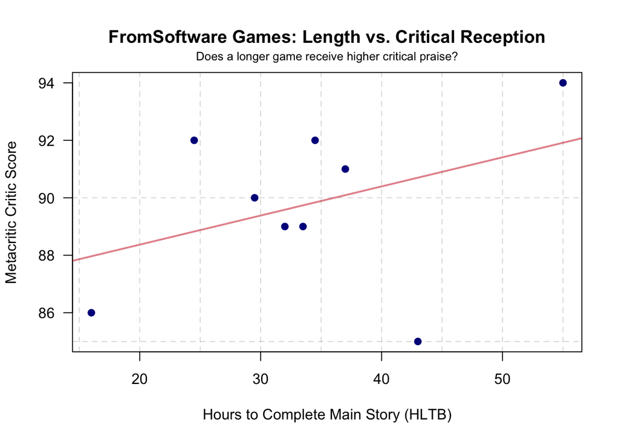

```r
# Load the data
game_data <- read_csv("fromsoftware_data.csv")

# Create the linear model
souls_model <- lm(`Puntuacion_Metacritic (Y)` ~ `Horas_HLTB (X)`, data = game_data)

# Create the scatterplot
plot(`Puntuacion_Metacritic (Y)` ~ `Horas_HLTB (X)`, data = game_data,
     pch = 20, col = "darkblue", cex = 1.5, las = 1,
     xlab = "Hours to Complete Main Story (HLTB)",
     ylab = "Metacritic Critic Score",
     main = "FromSoftware Games: Length vs. Critical Reception")
mtext(side = 3, text = "Does a longer game receive higher critical praise?", cex = 0.8, line = 0.5)

# Add the regression line
abline(souls_model, lwd = 2, col = rgb(0.8, 0.1, 0.1, 0.5))

# Add grid lines for reference
abline(h = seq(85, 95, 5), v = seq(15, 60, 5), lty = 2, col = rgb(0.2, 0.2, 0.2, 0.2))
```

The scatterplot above shows the relationship between game length (in hours) and Metacritic scores for 9 FromSoftware titles. While there appears to be a slight upward trend, the relationship is not particularly strong, as indicated by the wide dispersion of points around the regression line.

**Summary of the Regression**

```r
pander(summary(souls_model))
```

|  | Estimate | Std. Error | t value | Pr(>\|t\|) |
| --- | --- | --- | --- | --- |
| **(Intercept)** | 86.34 | 3.265 | 26.45 | 2.828e-08 |
| **`Horas_HLTB (X)`** | 0.1013 | 0.09211 | 1.1 | 0.3077 |

Fitting linear model: `Puntuacion_Metacritic (Y)` ~ `Horas_HLTB (X)`

| Observations | Residual Std. Error | $R^2$ | Adjusted $R^2$ |
| --- | --- | --- | --- |
| 9 | 2.868 | 0.1474 | 0.02561 |

Additionally, the $R^2$ value of **0.1474** indicates that only **14.74%** of the variation in Metacritic scores can be explained by game length. This is a weak relationship, suggesting that other factors—such as gameplay mechanics, story quality, graphics, technical performance, and innovation—play a much larger role in determining critical reception.

## Interpretation

This suggests that FromSoftware’s critical success is not driven by simply making games longer, but rather by the quality of the experience regardless of length. Critics appear to value the tight design, innovative gameplay, and artistic vision that FromSoftware brings to each title, whether the game takes 16 hours (*Armored Core 6*) or 55 hours (*Elden Ring*) to complete.

## Validation of Model Appropriateness

To assess whether the linear regression model is appropriate for this data, we examine the residual plots below. These diagnostic plots help us verify the assumptions of linear regression: linearity, constant variance (homoscedasticity), and normality of residuals.

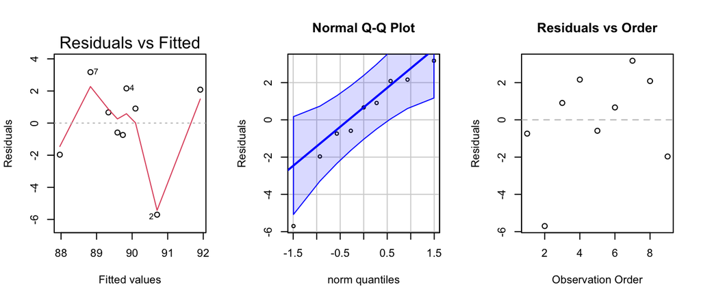

```r
par(mfrow = c(1, 3))

# Residuals vs Fitted Values (checks linearity and constant variance)
plot(souls_model, which = 1)

# Normal Q-Q Plot (checks normality of residuals)
qqPlot(souls_model$residuals, id = FALSE, main = "Normal Q-Q Plot", ylab = "Residuals")

# Residuals vs Order (checks for independence)
plot(souls_model$residuals, main = "Residuals vs Order",
     xlab = "Observation Order", ylab = "Residuals")
abline(h = 0, lty = 2, col = "gray")
```

Overall, the diagnostic plots suggest that the linear regression model is appropriate for this data, even though the relationship between game length and Metacritic score is not statistically significant.

## Conclusion

This analysis sought to determine if a statistically significant linear relationship exists between the length of a FromSoftware game’s main story (in hours) and its professional Metacritic score.

The results from the simple linear regression model show that **no statistically significant relationship exists** (p-value = 0.308). We fail to reject the null hypothesis at the $\alpha = 0.05$ significance level and conclude that game length is not a significant predictor of a game’s Metacritic score.

The low $R^2$ value of **14.74%** indicates that the vast majority of variation in Metacritic scores is explained by factors other than game length, such as gameplay mechanics, story quality, graphics, technical performance, and overall design philosophy.

In summary, while the data showed a slight positive trend, the statistical analysis confirms that **for FromSoftware games, a longer playtime does not equate to a higher critical review score**. Quality, not quantity, appears to be the determining factor in critical acclaim.

## The Data

For reference, here is the complete dataset used in this analysis:

```r
datatable(game_data, options = list(pageLength = 10))
```

|  | Game | Platform (for Metacritic) | Horas_HLTB (X) | Puntuacion_Metacritic (Y) |
| --- | --- | --- | --- | --- |
| 1 | Demon's Souls (2009) | PS3 | 33.5 | 89 |
| 2 | Dark Souls | PC | 43 | 85 |
| 3 | Dark Souls II | PC | 37 | 91 |
| 4 | Bloodborne | PS4 | 34.5 | 92 |
| 5 | Dark Souls III | PC | 32 | 89 |
| 6 | Sekiro | PC | 29.5 | 90 |
| 7 | Demon's Souls (Remake) | PS5 | 24.5 | 92 |
| 8 | Elden Ring | PC | 55 | 94 |
| 9 | Armored Core 6 | PC | 16 | 86 |